# Final_Project

## Data Quality

### Missing Data

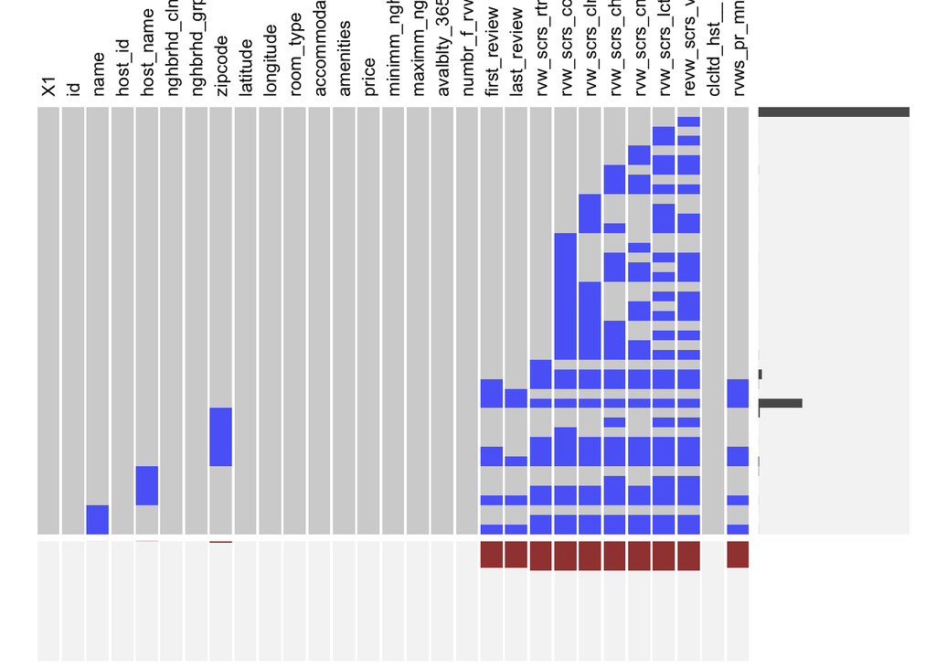

```r
options(warn=-1)

library(readr)
library(extracat)
library(tidyverse)
library(vcd)
library(RColorBrewer)
library(stringr)
library(vcd)

listings_short <- read_csv("~/Desktop/Columbia/Spring 2018/EDAV/Final_Project/cleaned_data.csv",col_types = cols())

visna(listings_short)
```

```r
d<-filter(listings_short,is.na(last_review))
summary(d$number_of_reviews)
```

```
##      Min.   1st Qu.    Median      Mean   3rd Qu.      Max.
## 0.0000000 0.0000000 0.0000000 0.0008272 0.0000000 1.0000000
```

Missing data in the dataset has the following main patterns:

Although in the plot above we see blue patterns frequently, the bars on the right indicate that there are only two major patterns – no missing data, and data that are missing socre information + review information (first, last review, reviews per month) altogether.

We suspect that these rows are missing information because they have low or zero reviews in place. To validate this hypothesis, we filtered the dataset to the ones that are missing ‘last review’, and found that almost all of these rows have 0 number of reviews. This explains the missing data pattern – these places have very few or no reviews, and therefore are also missing score information that’s most likely to be filled when users choose to leave a comment.

## Exploratory Part

### Overview

Next, we are interested to find out how many listings there by boroughs, and also what the most popular NYC neighbourhoods are on Airbnb.

```r
listing_by_borough <- listings_short %>% group_by(neighbourhood_group_cleansed) %>% summarize(count = n(),avg_price = mean(price),ttl_num_rev = sum(number_of_reviews))

listing_by_borough
```

```
## # A tibble: 5 x 4
##   neighbourhood_group_cleansed count avg_price ttl_num_rev
##   <chr>                        <int>     <dbl>       <int>
## 1 Bronx                          879      85.8       16154
## 2 Brooklyn                     20445     117        359156
## 3 Manhattan                    22153     183        417541
## 4 Queens                        5079      95.9      103206
## 5 Staten Island                  296     127          6176
```

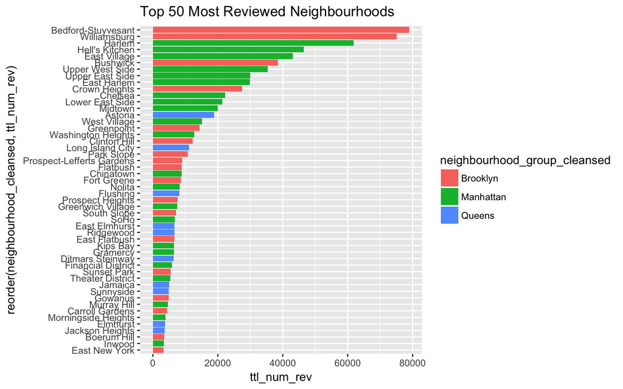

```r
most_popular_neighbourhood <- listings_short %>% group_by(neighbourhood_group_cleansed,neighbourhood_cleansed) %>% summarize(count = n(),avg_price = mean(price),ttl_num_rev = sum(number_of_reviews)) %>% arrange(desc(ttl_num_rev))

most_popular_neighbourhood<-head(most_popular_neighbourhood,50)

most_expensive_neighbourhood <- listings_short %>% group_by(neighbourhood_group_cleansed,neighbourhood_cleansed) %>% summarize(count = n(),avg_price = mean(price),ttl_num_rev = sum(number_of_reviews)) %>% arrange(desc(avg_price))

most_expensive_neighbourhood<-head(most_expensive_neighbourhood,50)

ggplot(most_popular_neighbourhood, aes(reorder(neighbourhood_cleansed,ttl_num_rev), ttl_num_rev,fill=neighbourhood_group_cleansed)) + geom_col() + coord_flip()+
  ggtitle("Top 50 Most Reviewed Neighbourhoods")
```

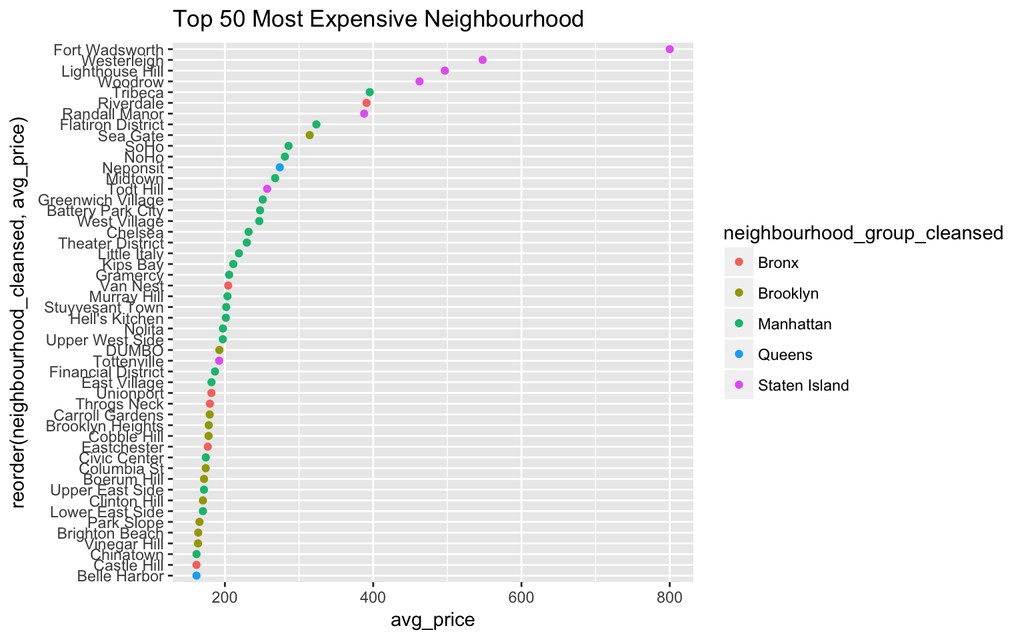

```r
ggplot(most_expensive_neighbourhood, aes(avg_price,reorder(neighbourhood_cleansed,avg_price))) + geom_point(aes(colour=neighbourhood_group_cleansed)) +
  ggtitle("Top 50 Most Expensive Neighbourhood")
```

```r
#
# listings_short<-listings_short %>% arrange(desc(number_of_reviews))
# most_popular_single_listings <- head(listings_short,10)
# most_popular_single_listings
```

### Price Distribution

#### Outliers

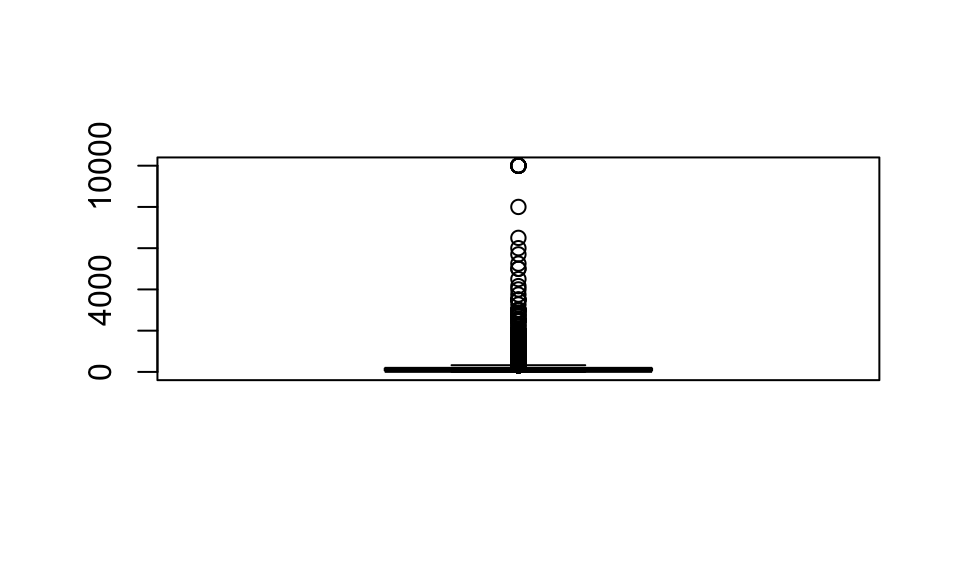

```r
boxplot(listings_short$price)
```

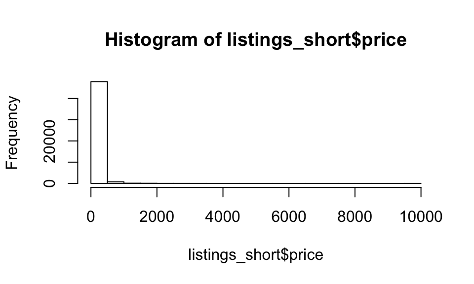

```r
hist(listings_short$price)
```

```r
summary(listings_short$price)
```

```
##    Min. 1st Qu.  Median    Mean 3rd Qu.    Max.
##     0.0    65.0   100.0   144.3   170.0 10000.0
```

We then looked at the price per night range of all the listings, trying to identify outliers. We found that the vast majority of listings have a prive lower than 2000. In order to draw informative histrograms, we only kept observations with a price lower than 750.

#### Price Histrograms

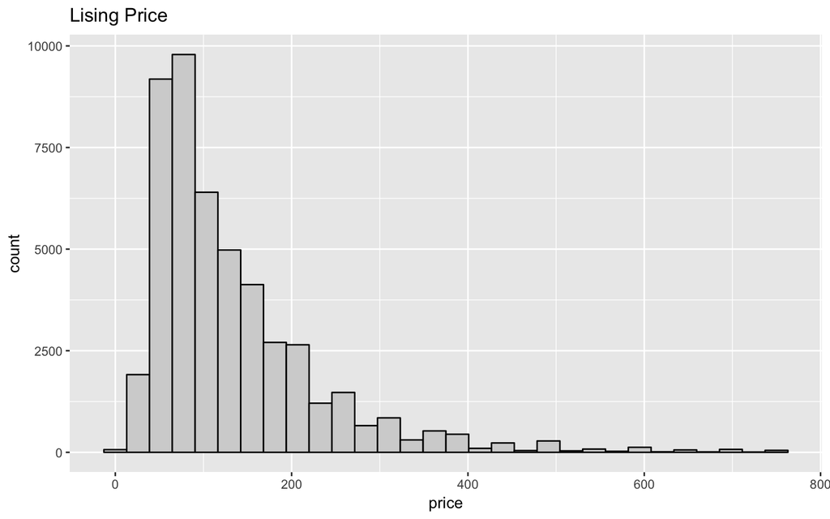

```r
listing_by_borough <- listings_short %>% group_by(neighbourhood_group_cleansed) %>% summarize(count = n(),avg_price = mean(price),avg_num_rev = mean(number_of_reviews))

listing_leq_750 <- listings_short %>% filter(price<=750)

ggplot(listing_leq_750, aes(price)) +
  geom_histogram(color = 'black', fill = 'lightgray') +
  ggtitle("Lising Price")
```

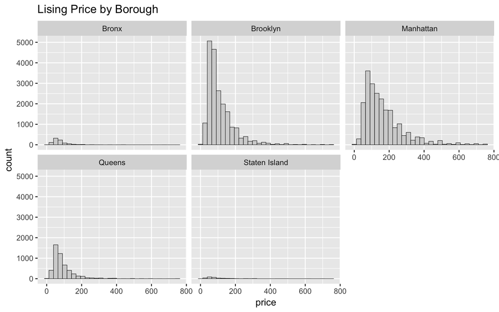

```r
ggplot(listing_leq_750, aes(price)) +
  geom_histogram(color='black',size=0.2,fill='lightgray') +
  facet_wrap(~neighbourhood_group_cleansed)+
  ggtitle("Lising Price by Borough")
```

Here we want to explore the distribution of listing prices. We first plotted an overall histrogram and learned that most listings are under $200 per night, and the most common prices are between $50 to $100.

We then faceted on borough, and further divided by room types. We can see that price distribution in Brooklyn is more right skewed than Manhattan, meaning that the prices in Brooklyn are in general lower than Manhattan.

### Room Types

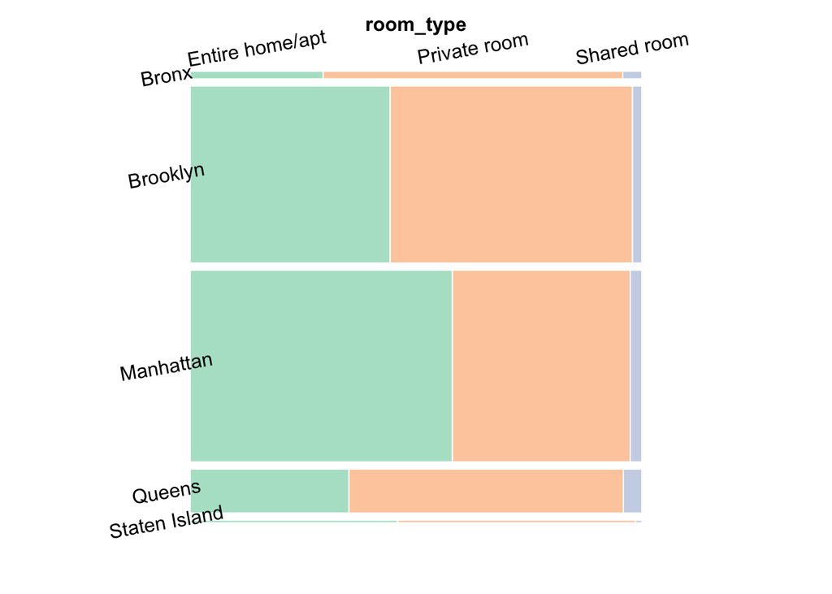

```r
mosaic(room_type ~ neighbourhood_group_cleansed, listings_short,gp = gpar(fill =brewer.pal(3, "Pastel2"), col = "white"),labeling = labeling_border(varnames=c(FALSE,TRUE),rot_labels = c(10,0,0,10)))
```

Next we are interested to see how room types are correlated with boroughs. Here we see that Manhattan hosts are more likely to list entre home/apt, while Queens and Brooklyn hosts are more likely to list private room within a house. Shared room takes very low share across all boroughs.

#### Room Types + Price

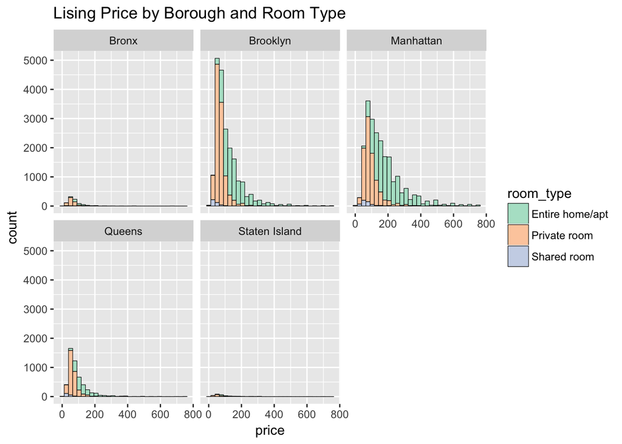

```r
ggplot(listing_leq_750, aes(price, fill = room_type)) +
  geom_histogram(color='black',size=0.2) +
  facet_wrap(~neighbourhood_group_cleansed)+
  ggtitle("Lising Price by Borough and Room Type") +
  scale_fill_brewer(palette = 'Pastel2')
```

When combine room types and listing prices, we see that as price goes up, room type “Entire home/apt” starts to take a higher percentage. And this is true across all boroughs.

### Pet Policy

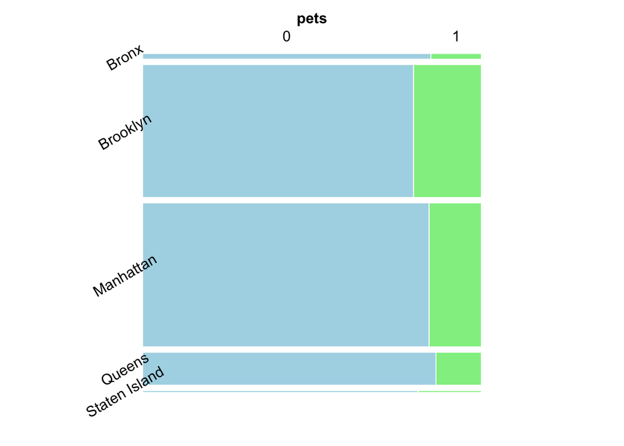

```r
listings_pets <- read_csv("~/Desktop/Columbia/Spring 2018/EDAV/Final_Project/listings_pets.csv", col_types = cols())

ls_pets <- listings_pets %>%
  mutate(pets = ifelse(str_detect(amenities,'pets allowed') | str_detect(amenities,'cat') | str_detect(amenities,'dog'),1,0))

ls_pets <- ls_pets %>%
  mutate(dog = ifelse(str_detect(amenities,'dog'),1,0))

ls_pets <- ls_pets %>%
  mutate(cat = ifelse(str_detect(amenities,'cat'),1,0))

ls_pets <- ls_pets %>%
  mutate(Unspecified_Other = ifelse(cat==0 && dog==0,1,0))

ls_pets <- ls_pets %>%
  mutate(pet_category = ifelse(cat==1,'Cat',ifelse(dog==1,'Dog',ifelse(cat==0 && dog==0,'Unspecified'))))

pets_only<-filter(ls_pets,pets==1)

mosaic(pets ~ neighbourhood_group_cleansed, ls_pets, gp = gpar(fill = c('lightblue','lightgreen'), col = "white"), labeling = labeling_border(varnames=c(FALSE,TRUE),rot_labels = c(0,45,30,30)))
```

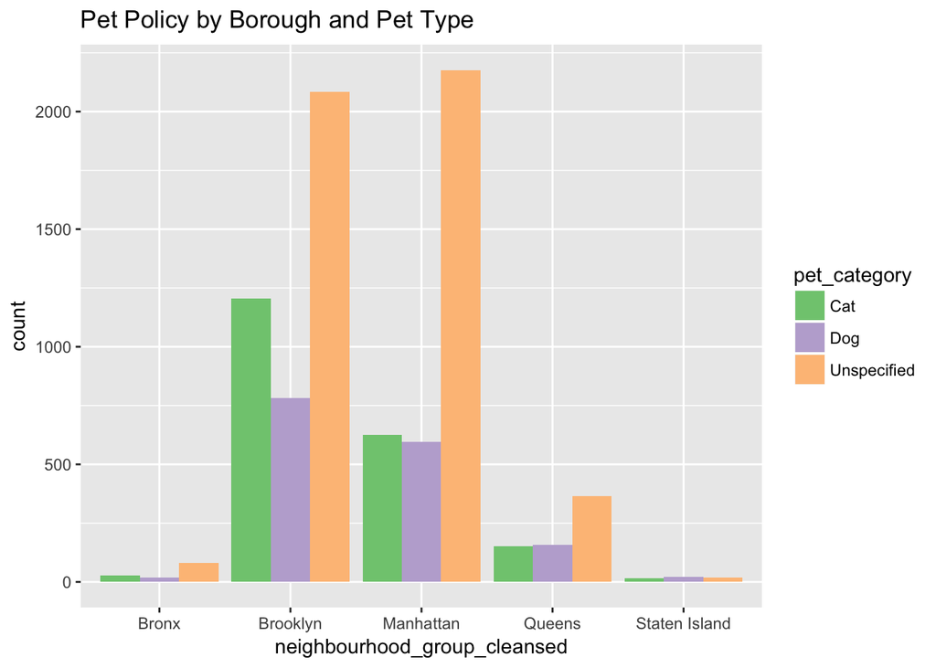

```r
ggplot(pets_only, aes(x=neighbourhood_group_cleansed, fill=pet_category)) +
  geom_bar(position='dodge') +
  scale_fill_brewer(palette = "Accent") +
  ggtitle('Pet Policy by Borough and Pet Type')
```

We are also curious to see what the pet policy looks like. From the mosaic plot we see that only a small percentage of listings are willing to accept pets, across all boroughs. Brooklyn is slightly more pet friendly, compared to the others.

```r
# library("tm")
# library("SnowballC")
# library("wordcloud")
# library("RColorBrewer")
# file_path<-"~/Desktop/Columbia/Spring 2018/EDAV/Final_Project/name.txt"
# text<-readLines(file_path)
# docs <-Corpus(VectorSource(text))
# toSpace <- content_transformer(function (x , pattern ) gsub(pattern, " ", x))
# docs<- tm_map(docs, toSpace, ',')
# docs <- tm_map(docs, content_transformer(tolower))
# docs <- tm_map(docs, removeWords, stopwords("english"))
# docs <- tm_map(docs, removeWords, c("room","bedroom","apartment","apt"))
# dtm <- TermDocumentMatrix(docs)
# m <- as.matrix(dtm)
# v <- sort(rowSums(m),decreasing=TRUE)
# d <- data.frame(word = names(v),freq=v)
# head(d, 10)
# set.seed(1234)
# wordcloud(words = d$word, freq = d$freq, min.freq = 1,
#           max.words=200, random.order=FALSE, rot.per=0.35,
#           colors=brewer.pal(8, "Dark2"))
```